# Ann Arbor Public Schools Fiscal Crisis - Comprehensive Research Report

Fiscal Structure, Demographic Trajectory, and School Closure Outlook

September 9, 2026

# Executive Summary

Ann Arbor Public Schools (AAPS) faces a structural fiscal crisis driven by a declining school-age population, a state funding formula tied to per-pupil counts, and a decade of staffing growth that preceded the 2024 budget shock. This report consolidates four parallel research tracks (district and government sources, state-level policy, social media sentiment, and local journalism) with a tract-level demographic analysis of the district’s population from ACS 5-year data covering 2005-2009 through 2020-2024.

# Part I: Fiscal Structure - Why a Wealthy District Runs Deficits

## The Two-Ledger System (Proposal A, 1994)

Michigan’s 1994 constitutional amendment (Proposal A) split every district’s finances into two sealed ledgers. Capital projects (new buildings) are funded by local property taxes and voter-approved bonds; operating costs (salaries, buses, utilities) are funded by the state on a per-pupil basis. Money cannot move between them. This is why AAPS can simultaneously build new schools from its 2019 $1B bond while cutting operating staff: the bond proceeds cannot legally pay a single teacher salary.

The 2019 bond’s purchasing power has since collapsed under 44.4% construction inflation. In February 2026 the district announced no new projects would break ground this year: four elementary rebuilds (Mitchell, Dicken, Logan, Thurston) continue; eight projects (Abbot, Carpenter, King, Lakewood, Lawton, Pittsfield, Wines, Pathways) are frozen pending re-estimation, with recommendations due end of 2026. A sinking-fund renewal (2.4031 mills, $33.8M first year) passed August 4, 2026 with 74.2% support; without it the district faced a $582.7M capital gap and negative cash flow by 2028.

## The Operating Ledger

Salaries and benefits consume 79.6% of general-fund spending. The district added roughly 480 positions (2024 superintendent’s letter; the budget briefing states +272 FTE - the discrepancy is unresolved) over a decade while enrollment fell back to early-2010s levels.

## The 2024 Budget Shock and Its contested Narrative

In spring 2024, a third-party forensic review (Plante Moran) found that the budget had been built by copying the prior year’s spreadsheet: a $14M state pension transfer (MPSERS 147c2) was recorded as revenue without the matching expenditure. Early media framed this as a “$25M accounting error.” The forensic report’s actual finding was that the misposting had **zero net impact on fund balance**; the real driver was the ~$12M compensation increase approved by the board in March-April 2023, which would have required 1,130+ additional students to balance. The superintendent at the time (Jeanice Swift) was bought out in September 2023 (18 months’ salary, ~$345K). Current superintendent Jazz Parks earns $256,000 under a contract through June 2027.

## State Funding Environment

Per-pupil foundation allowances rose two consecutive years: $10,050 in 2025-26 (+4.6%, PA 15 of 2025) and $10,300 in 2026-27 (+2.5%, PA 25 of 2026, signed July 21, 2026). AAPS, as a hold-harmless district, receives more (~$11,172), but enrollment decline (16,956 to ~16,372 over five years) has shrunk the total foundation from $179.6M to $175.2M. The July 2026 package (SB 903 + HB 5630 Sec. 22b) created the largest formula change since Proposal A - weighted funding for at-risk and ELL students phasing in over 15 years (+$278M statewide, +20%) - but moves by statute, not constitutional amendment; Proposal A’s capital/operating wall stands.

AAPS is under no state intervention: it is absent from the Early Warning list (28 districts), the deficit-elimination list (4 districts), and has no state oversight. It entered and exited Treasury’s “potential fiscal stress” monitoring between June 2024 and December 2025.

The Washtenaw Intermediate School District functions as the county-level relief valve: a special-education millage renewal (2.3826 mills, 12 years, ~$56.9M/year) shields AAPS from ~$25M/year of mandated special-education costs, and a new CTE millage (1 mill, ~$25M/year) passed in 2025.

## The Tax-Base Squeeze from City Hall

In May 2026 the county approved a $300M “Ann Arbor South” brownfield TIF that will capture roughly $135M of school-district education tax over 30 years. The district publicly opposed it and lost. City and county economic-development decisions are actively eroding the district’s tax base - a structural headwind independent of enrollment.

# Part II: Demographic Analysis - A District Aging in Place

## Fifteen-Year Age-Structure Trend

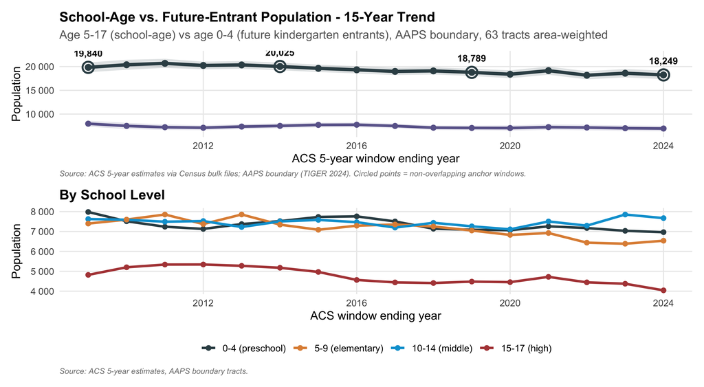

AAPS district age structure, ACS 5-year windows 2009-2024. Shaded band: 90% margin of error (independent-sum approximation). Non-overlapping anchor windows marked.

The district-level numbers (Table 1) show the pattern: **total population up 6.8%, school-age down 8.0%, future entrants down 12.7%.** The district is not losing residents; it is losing children. The 0-4 cohort sits at its 15-year low in the 2020-2024 window with no recovery inflection - meaning elementary enrollment pressure continues at least through 2030.

Non-overlapping anchor windows (independent samples). Source: ACS 5-year estimates, AAPS boundary, 63 tracts area-weighted.

| Window ending | 0-4 | 5-9 | 10-14 | 15-17 | 5-17 |
| --- | --- | --- | --- | --- | --- |
| 2,009 | 7,981 | 7,397 | 7,626 | 4,818 | 19,840 |
| 2,014 | 7,520 | 7,344 | 7,506 | 5,176 | 20,025 |
| 2,019 | 7,087 | 7,048 | 7,259 | 4,481 | 18,789 |
| 2,024 | 6,965 | 6,536 | 7,671 | 4,042 | 18,249 |

# Part III: Geographic Divergence - Where the Children Left

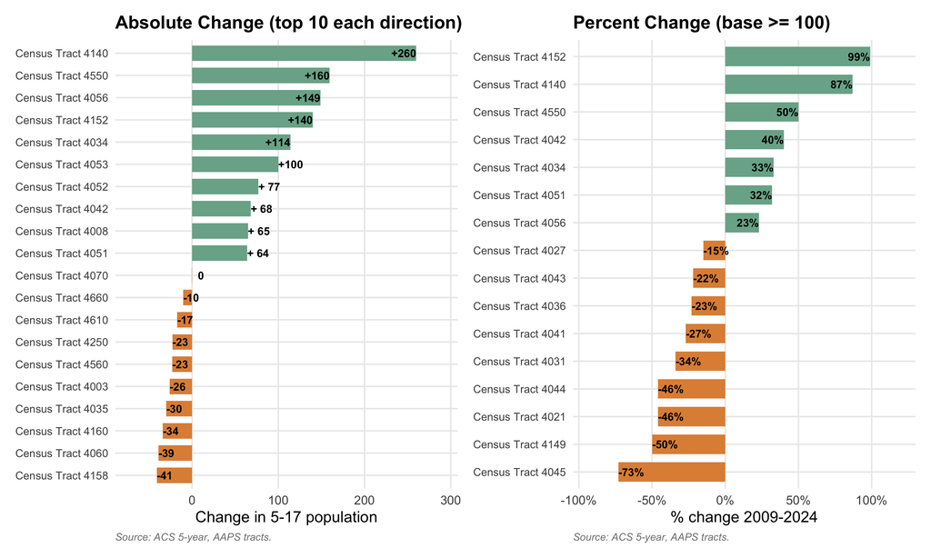

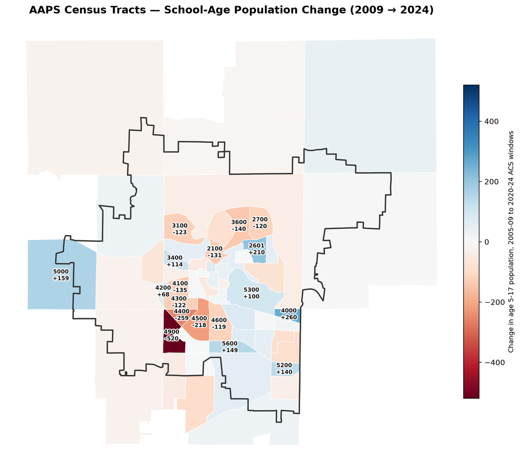

Choropleth of census-tract school-age population change. Red = loss, blue = gain; bold labels mark tracts with absolute change of at least 100 or relative change of at least 40% (base at least 100). Black outline: AAPS district boundary (TIGER 2024).

## Interpretation for Closure Risk

Three factors compound the demographic arithmetic for specific schools: (1) small inner-ring schools with aging buildings deferred from the bond rebuild list; (2) attendance areas overlying the steepest-decline tracts; (3) proximity to a newer, larger replacement school that could absorb enrollment. No public list of candidate schools exists as of this writing (September 9, 2026); any specific names circulating on social media are unverified. The board’s stated timeline - decision in fall 2026, effective fall 2027 - places the announcement within roughly two to four months of this report.

# Part IV: Social and Political Landscape

## Labor

Local teacher testimony on Reddit corroborates attrition pressure: self-reported exits of 11-13 staff from a single elementary school, dual-teacher households claiming $60K/year more in neighboring districts, and salary comparisons (Wayne-Westland +$15K) - all unverified but directionally consistent with Michigan State University research finding Michigan teachers’ real wages declined more than any state’s over the past decade.

## Community Factions

Public sentiment on r/AnnArbor splits into a dominant accountability faction (blaming the administration, with calls for Superintendent Parks to resign) and a structural-funding faction (blaming Proposal A and per-pupil state funding, advocating a countywide operating millage). Teacher first-person testimony clusters on Reddit; X/Twitter discussion is dominated by institutional accounts with far less first-hand content. No specific school names have circulated in open social media - closure-list rumors, if they exist, live in closed Facebook parent groups outside this research’s reach.

# Part V: Consolidated Timeline of Key Events

Consolidated from four research tracks; see Sources.

[output not shown]

# Sources

1. AAPS official documents - budget presentations, board materials, bond program updates, personnel contracts (a2schools.org), retrieved September 9, 2026. Full inventory: `sources/official-gov.md` in the project repository.
2. Michigan Treasury quarterly early-warning and deficit reports; MDE; Michigan Legislature (SB 166/PA 15-2025, HB 5630/PA 25-2026, SB 903); MiSchoolData. Inventory: `state-level.md`.
3. ACS 5-year estimates 2005-2009 through 2020-2024, Census bulk summary files (www2.census.gov), tract-level B01001 age-sex counts for 63 AAPS-boundary tracts, area-weighted. Pipeline: `population/` directory.
4. Ann Arbor Observer (Aug 26, 2026, paywalled); MLive/annarbornews; Michigan Daily; WEMU; Michigan Public. Inventory: `local-news.md`.
5. r/AnnArbor threads (11 analyzed) and X/Twitter search. Inventory: `social-media.md`.
6. TIGER/Line 2024 school-district and tract shapefiles (unified school districts, tracts), U.S. Census Bureau.